None

# SAE Classement ParcourSup Département Informatique

### Sommaire

- Contexte du Projet
- Mise en place
- Summary of the implementation
- Données
  - Nombres de candidatures
  - Matrice de traîtements
  - Récupération des données
  - Créations de DataFrames
  - Renormalisation et classement candidats
  - Summarize functions in English
  - Création d'un fichier excel
- Statistiques
  - Statistique Avant et Après Filtres
  - Statistiques des Établissements des Candidats
  - Départements des candidats
- Conclusion

# Contexte du projet

Le projet consiste à créer un classement des candidats pour la filière Informatique de l'IUT de Villetaneuse Sorbonne Paris Nord pour l'année 2022/2023. Cette tâche a été confiée à notre groupe dans le cadre d'un projet.

Nous avons reçu un fichier Excel contenant les données de ParcourSup, qui regroupe toutes les demandes des étudiants pour rejoindre cette filière. L'objectif est de sélectionner les meilleurs candidats et de présenter les résultats sous forme d'un classement clair et facile à comprendre pour les chefs de département.

Ce projet est important car il permettra de faciliter la tâche des chefs de département en leur fournissant un classement clair des candidats pour la filière Informatique. De plus, ce projet permettra de garantir que les meilleurs candidats soient sélectionnés pour rejoindre cette filière, ce qui est bénéfique pour l'IUT de Villetaneuse Sorbonne Paris Nord ainsi que pour les étudiants sélectionnés.

Notre groupe travaillera donc à partir des données de ParcourSup pour créer un classement des candidats à la filière Informatique pour l'année 2022/2023. Nous veillerons à ce que le classement soit clair, précis et facile à comprendre pour les chefs de département.

Accéder au sommaire

# Mise en place

Le projet consiste à créer un algorithme permettant d'automatiser le classement ParcourSup, avec pour seul utilisateur le chef de département ou la personne en charge des candidatures. L'équipe chargée de ce projet est composée de Karim et Djibril. Les candidats à filtrer ont plusieurs formations (Série Générale, DAEU, Licence, Fac, Filière Scientifique et/ou Economie et Sociale), et doivent être triés en fonction de la validation de leur candidature, leur dernière formation et leurs notes trimestrielles ou de baccalauréat. Le projet devait initialement être réalisé en un mois, mais a été étendu d'un mois supplémentaire.

Pour répondre à cette problématique, l'utilisation de Jupyter Notebook avec Python a été recommandée, ainsi que les modules Pandas et Matplotlib pour la gestion de dataframes et la génération d'illustrations. L'objectif du projet était de créer un script capable de répondre aux besoins en moins de 5 minutes, cependant, des manques d'informations ont ralenti la progression du projet, notamment pour la formation 'Série Générale'.

Les critères de succès du projet étaient d'abord de réussir le filtrage des candidats selon leur dernière formation, puis de sélectionner ceux ayant toutes les notes nécessaires au classement. Ensuite, la première normalisation des moyennes des notes trimestrielles a été réalisée, suivie d'une seconde normalisation pour obtenir des notes comprises entre 0 et 20. Plusieurs dataframes ont été créés pour les différentes formations (Généraux, STI2D, manuels, et éliminations), et un fichier Excel final avec les quatre dataframes devait être généré.</p> Accéder au sommaire

# Summary of the implementation

## Project Objectives

- Create an algorithm to largely automate the ParcourSup ranking process

## Users and Team

- Single user: Head of Department or person in charge of ParcourSup applications
- Team: Karim and Djibril, both commissioned to complete the project

## Project Description

- Multiple candidate pathways: General Series, DAEU, License/Faculty, Scientific and/or Economic and Social Streams
- Candidates filtered based on their application validation, last educational attainment and quarterly/baccalaureate grades
- Quarterly and baccalaureate grades normalized to facilitate ranking
- Uses Jupyter Notebook with Python and the Pandas and Matplotlib modules
- Goal: create a script meeting requirements in less than 5 minutes
- Success criteria: successful candidate filtering, successful initial normalization, successful renormalization of grades between 0 and 20
- Creation of multiple dataframes for different candidate types
- Program finalized with output of an Excel file containing the 4 dataframes
- Analysis of provided Excel file, use of tutorials to master necessary tools for the project, contact with Mr. Dubacq (former Head of the Computer Science Department), choice of the same criteria as the SD (Data Science) department

Go to the table of contents

# Données

Dans un premier temps, on importe, tous les modules nécessaires à ce projet, notamment :

- `pandas` pour manipuler et analyser les données ;
- `math.isnan` pour vérifier si une valeur est NaN ;
- `time` pour mesurer le temps d'exécution ;
- `numpy` pour effectuer des calculs mathématiques sur des tableaux ;
- `matplotlib.pyplot` pour créer des graphiques.

Accéder au sommaire

On récupère la DataFrame de l'Excel en utilisant la méthode suivante :

```
df = pd.read_excel("PS_INFO.xlsx",engine='openpyxl')
```

# Nombres de Candidatures

Le programme effectue un traitement sur une DataFrame appelée "df", qui contient des informations sur les candidatures. Il récupère la taille de la DataFrame et initialise des variables pour compter le nombre de vœux non confirmés, de bacs généraux et de bacs technologiques. Ensuite, il parcourt chaque ligne de la DataFrame et effectue des calculs pour chaque ligne. Enfin, il affiche les résultats sous forme de texte.

```
Nombre de vœux  total : 4605
Nombre de vœux non confirmés : 243
Nombre de vœux confirmés : 4362
Dont 2972 bacs généraux et 1390 bacs technologiques
```

Nous avons un code qui crée deux tableaux (appelés "dataframes" en langage informatique) qui contiennent des informations sur les matières étudiées dans deux types de baccalauréat différents.

- Le premier tableau, appelé "MATRICE_G", concerne les bacs généraux et contient des notes (coefficients) pour les matières suivantes : mathématiques, NSI, SES, anglais et français.
- Le deuxième tableau, appelé "MATRICE_T", concerne les bacs technologiques et contient des notes (coefficients) pour les matières suivantes : mathématiques, NSI, anglais et français.

Ces tableaux sont créés à l'aide du module "pandas" et sont stockés dans des variables appelées "MATRICE_G" et "MATRICE_T".

```
Matrice pour les bacs Généraux :
         MATH  NSI  SES  ANGLAIS  FRANCAIS
P1          1    1    1        1         1
P2          2    1    1        1         1
P3          3    1    1        1         1
T1          2    2    2        1         1
T2          3    2    2        1         1
T3          4    2    2        1         1
COEF       13    6    5        4         9
PLANCHE     8    8    7        8         8


Matrice pour les bacs Technologiques:
         MATH  NSI  ANGLAIS  FRANCAIS
P1          1    1        1         1
P2          2    1        1         1
P3          3    1        1         1
T1          2    2        1         1
T2          3    2        1         1
T3          4    2        1         1
COEF       13    6        4         9
PLANCHE    10    9        8         8
```

Accéder au sommaire

### Récupération des données

Dans un premier temps, notre objectif est de normaliser les notes des candidats pour permettre une comparaison plus juste entre eux. Nous avons identifié trois possibilités pour ce faire :

- Les candidats qui ont des notes de baccalauréat uniquement.
- Les candidats qui ont seulement des notes trimestrielles.
- Les candidats qui ont des notes dans les deux conditions.

Après avoir analysé le fichier Excel, nous avons conclu que :

- Les anciens bacs, série scientifique et économique et sociale, appartiennent à la première catégorie. Par conséquent, nous classons ces candidats en fonction de leurs notes de baccalauréat, et nous devons donc normaliser leurs notes de baccalauréat.
- Les candidats de série générale auraient dû avoir des notes trimestrielles, nous les noterons donc en fonction de leurs notes trimestrielles. Nous devrons normaliser leurs notes de trimestres.
- Les candidats de la série STI2D ont des notes pour le baccalauréat et pour les notes trimestrielles. Nous avons choisi de les noter en fonction de leurs notes trimestrielles, car tous avaient des notes trimestrielles. Pour les notes des épreuves du nouveau baccalauréat, tous n'ont pas encore leurs notes disponibles.

Après avoir normalisé les notes trimestrielles, nous devons calculer les moyennes des notes normalisées pour chaque trimestre. En utilisant les coefficients correspondants, nous pouvons ensuite calculer les moyennes de chaque matière sur les deux années. Cependant, les candidats évalués sur la base de leurs notes de Baccalauréat ne sont pas pris en compte dans le calcul des moyennes par trimestre, car ils n'ont qu'une seule note.

Nous effectuons également une étape importante de vérification, en veillant à la présence de notes essentielles dans les dossiers des candidats :

- Pour les candidats issus des filières scientifiques et économiques et sociales, nous vérifions la présence de notes d'épreuves de français qui ont été passées un an avant les candidatures Parcoursup, et qui sont donc obligatoires.
- Pour les candidats notés sur leurs moyennes trimestrielles, nous vérifions la présence de notes pour toutes les matières, qui sont requises pour l'évaluation et le classement.

Accéder au sommaire

# Créations de DataFrames

Ainsi, nous créons deux dossiers par candidat :

- Un dossier contenant la validation ou non du candidat, son numéro de candidature, son sexe, s'il a choisi l'anglais et s'il le fait en LV1 ou LV2, sa filière, sa dernière formation, l'année d'obtention de son baccalauréat, et s'il a bénéficié d'une bourse lors de sa dernière année. Nous y incluons également des informations diverses sur son dernier établissement, telles que son nom, sa commune et son département. Finalement, nous avons une colonne "Commentaires" qui nous sert à nous informer dans deux cas : lors de son élimination, le motif de l'élimination, et si sa candidature a été mise à faire manuellement, pourquoi, par exemple en cas de manque d'une note "X", ou s'il est issu d'une formation qui est mise à l'étude manuelle automatique, comme les DAEU-B.
- Le second dossier prend trois formes, en fonction de la dernière formation du candidat et des matières étudiées. Ce dossier des notes permet, dans le cas où le candidat est à classer, de contenir ses notes normalisées de Première et de Terminale, ou des épreuves de baccalauréat, puis de normaliser ces notes une seconde fois selon sa catégorie.

Nous avons créé plusieurs modèles de données pour notre processus de sélection, notamment `ELIMINATION` pour les candidats éliminés, `FICHE_CANDIDATS_MANUEL` pour les candidats dont les informations et/ou les notes sont incomplètes, `FICHE_STI2D` et `NOTE_STI2D` pour les candidats STI2D à classer, et `FICHE_GENERAUX` et `NOTE_GENERAUX` pour les candidats généraux faisant partie du groupe `7415`.

Ensuite, nous affichons le nombre de candidats pour chaque modèle de données.

```
Il y a 3272 candidats non classés.
Il y a 171 candidats à classer en Généraux.
Il y a 624 candidats à classer en STI2D.
Soit 795 candidats à classer.
Il y a 538 candidats à classer manuellement.
```

Accéder au sommaire

# Renormalisation et classement candidats

On vient ensuite normaliser une seconde fois les notes des candidats, selon leurs dataframes, et par matière grâce à la formule $\frac{20}{x_{max}-x_{min}}(x-x_{min})$.

Pour ensuite calculer leur moyennes grâces aux coéfficient des matières, selon données dans le tableaux en debuts de rapport.

On créé ensuite une nouvelles dataframes avec les informations :

- Le classement du candidat
- Le numéro du candidat
- Le sexe du candidat
- L'année d'obtention du Baccalauréat
- Si le candidat possède une bourse
- Sa moyenne des notes normalisées
- Sa note renormalisée de Mathématiques
- Sa note renormalisée de Français
- Sa note renormalisée de Systèmes d'information et numérique ou d'Informatique et sciences du numérique, ou encore sciences économiques et sociales pour ceux qui ont choisi l'une de ces options
- Sa note renormalisée d'anglais

Accéder au sommaire

# Summarize functions in English

Using the function in our main function `recupDBC`, we create the following variables:

- `ELIMINATION`: information on unranked candidates
- `FICHE_CANDIDATS_MANUEL`: information on candidates with missing information to automate the process
- `FICHE_STI2D`: information on STI2D students and/or those who have taken an STI2D class who have been preselected
- `NOTE_STI2D`: Notes of preselected STI2D students
- `FICHE_GENERAUX`: information on preselected students who are or have already completed a General education program
- `NOTE_GENERAUX`: Notes of preselected General students

Among the collected data, we create a field `'Validation'` which takes three types of values: $0$ if we do not have enough information about the candidate, it will be `FICHE_CANDIDATS_MANUEL`; $-1$ if we do not have any grades for the student or if he/she does not correspond to the desired profile (for example, bac STMG or a DAEU-a in Literary), then it will be in `ELIMINATION`. And if `'Validation'` is equal to $1$, we normalize his/her grade using the other already normalized grades, with the formula $\frac{20}{x_{max}-x_{min}}(x-x_{min})$.  
For this purpose, we have several functions:

- `recupDBC(df, i)` which retrieves all the information (that interests us) from row i of the Excel file, which filters at several levels: checks the presence of grades in French, Mathematics, English, NSI or SIN
- `normalisation_bac(i, forme, epreuve)` and `normalisation_trimestre(df, i, matiere, trimestre)` which respectively normalize the Bac and Trimester grades of the student according to the case
- `MAT_FR(i)` and `BAC_FR(i)` which check for the presence of French grades
- `TRI_MANQUE` checks if the quarterly averages for a subject are missing for a given candidate, by looking if all the quarterly averages for the first or final year are missing. If yes, it returns "True", otherwise it returns "False".
- `normalize_notes(column)` and `moyenne_cand(df, num, coef)` The moyenne_cand function calculates the weighted overall average of a candidate in 5 subjects, while the normalize_notes function normalizes the grades of a column on a scale of 0 to 20. The code uses this function to normalize the grades in each subject.

Go to the table of contents

# Statistiques et Graphiques

Après avoir effectué le classement de nos données, nous avons utilisé la bibliothèque `Matplotlib` pour visualiser graphiquement les données brutes de notre fichier Excel, ainsi que les données triées générées par notre programme. Pour ce faire, nous avons créé différents types de graphiques tels que des histogrammes, des nuages de points et des graphes en barres. Nous avons également personnalisé ces graphiques en ajoutant des titres, des étiquettes d'axe et des légendes.

Accéder au sommaire

# Statistique Avant et Après Filtres

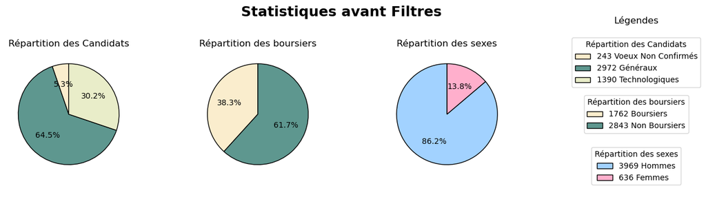

Dans un premier temps, nous analysons les données brutes de notre fichier Excel en vue d'extraire des informations pertinentes. Nous débutons par l'étude de la proportion des candidats selon leur groupe, à savoir s'ils sont issus de la filière générale ou technologique, ainsi que d'une troisième condition relative à la validation de leurs vœux. En cas de validation, nous identifions la filière choisie, sinon, nous considérons qu'ils ont des "Vœux non confirmés". Cette analyse nous permet de constater que la majorité des candidatures proviennent des candidats généraux et qu'il y a plus de 5 % des candidats qui n'ont pas validé leurs vœux.

Nous poursuivons notre étude en cherchant la répartition des boursiers parmi les candidats. Nous observons que près de 4 candidats sur 10 sont boursiers, ce qui peut avoir des implications importantes pour l'admission.

Enfin, nous examinons la proportion de candidates, qui est d'environ 14 %. Cette faible proportion de candidatures féminines souligne l'importance de la diversité dans les secteurs tels que l'informatique.

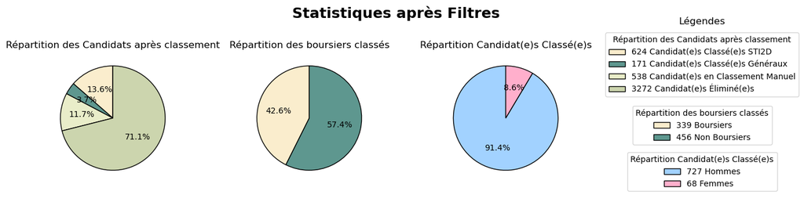

Après avoir appliqué le filtre, nous avons pu observer que près de 71% des candidatures ont été rejetées. Parmi les candidatures acceptées, nous avons recensé 624 candidats STI2D et 171 candidats généraux, soit un total de 795 candidats classés.

En outre, nous avons analysé la répartition des boursiers parmi les candidats classés et constaté une augmentation de plus de 4% par rapport aux données brutes.

Enfin, nous avons également examiné la proportion des sexes parmi les candidats classés. Nous avons observé une diminution de 5% de la proportion de femmes, passant de 636 candidates à 68 candidates. Cette tendance souligne le manque de candidatures féminines dans de nombreux secteurs, tels que l'informatique.

[figure not shown]

Nous disposons des nombres de candidates et de candidats éliminés, mis en étude manuelle et classés.

On observe que proportionnellement, bien que le nombre de candidates dans les données brutes soit de 13,8% (soit 69 candidates sur 500 candidats tous genres confondus), le nombre de femmes éliminées proportionnellement est supérieur à la proportion de femmes éliminées. En effet, la proportion de femmes classées est également inférieure à celle des hommes.

Si l'on examine proportionnellement le nombre de candidats (tous genres confondus), on constate que nous sommes plus proches des proportions des hommes que des femmes, lesquelles représentent un nombre largement inférieur de candidatures.

Grâce au graphique, nous pouvons également observer le nombre total de candidatures rejetées, classées et mises en étude manuelle.

Accéder au sommaire

# Statistiques des Établissements des Candidats

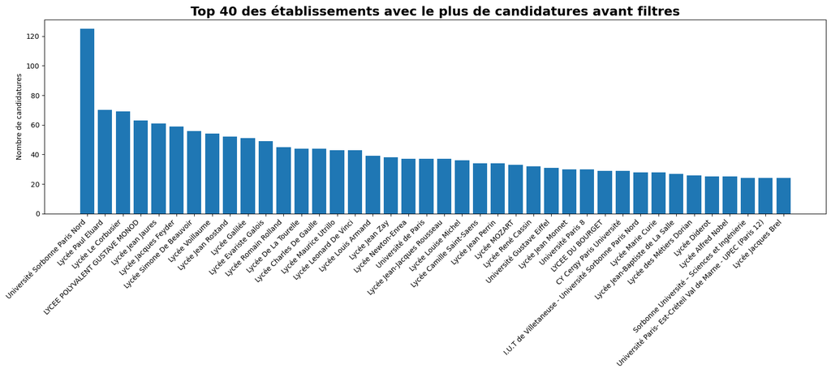

Ci-dessus, vous trouverez les 40 établissements ayant reçu le plus de candidatures, classés par nombre de candidatures. Les données sont basées sur le nombre de candidats ayant formulé au moins un vœu pour l'établissement.

Ci-dessous, vous trouverez le classement des établissements ayant reçu le plus de candidatures pour les filières Générales et STI2D, classés par nombre de candidatures.

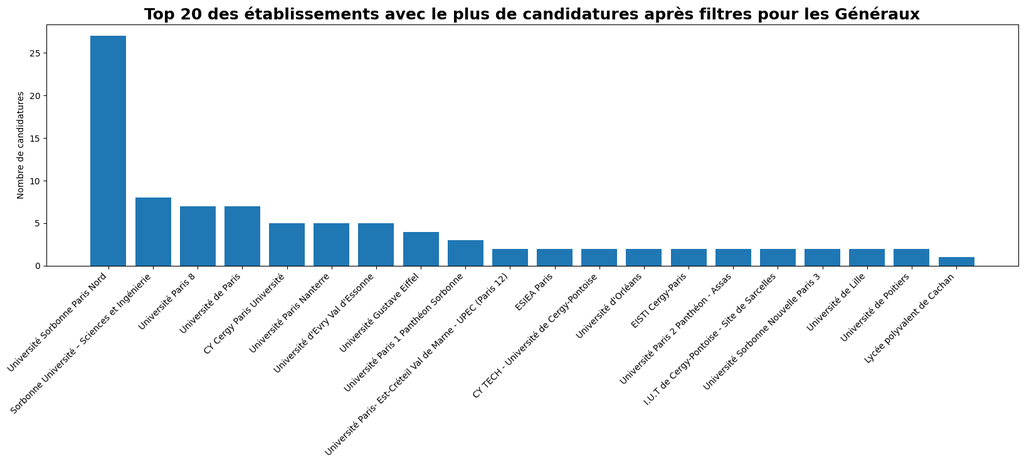

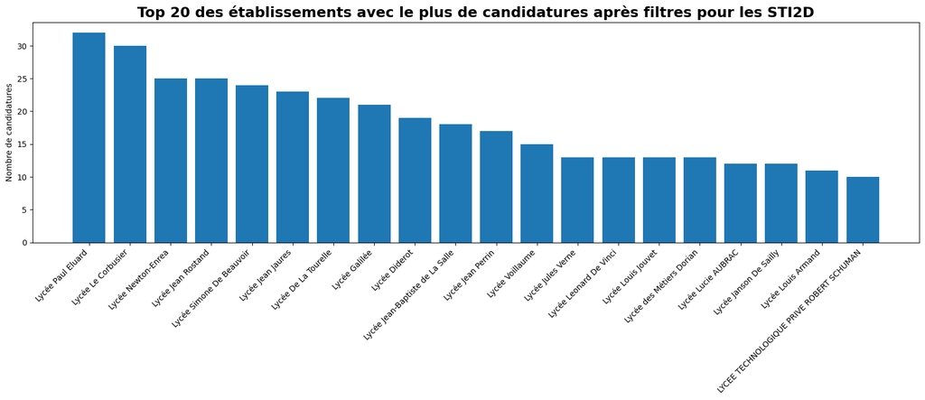

Nous avons cherché à identifier les établissements en commun entre le classement des établissements figurant dans le fichier Excel et le classement des établissements correspondant aux candidats généraux classés. Cette analyse nous a permis d'identifier les établissements en commun entre le premier graphique et les candidats classés en Général :

|  | 1 et 2 | 3 et 4 | 5 et 6 | 7 et 8 | 9 et 10 |
| --- | --- | --- | --- | --- | --- |
| 1 | Université Sorbonne Paris Nord | Lycée Jean Jaures | Lycée Voillaume | Université de Paris | Université Gustave Eiffel |
| 2 | Université Paris 8 | CY Cergy Paris Université | I.U.T de Villetaneuse - Université Sorbonne Pa... | Sorbonne Université – Sciences et Ingénierie | Université Paris- Est-Créteil Val de Marne - U... |

Nous avons effectué une étude pour déterminer les établissements présents à la fois dans le classement des établissements issus du fichier Excel et celui des établissements associés aux candidats classés en STI2D. Cette analyse nous a permis d'identifier les établissements communs entre le premier graphique et les candidats STI2D classés :

|  | 1 à 7 | 8 à 14 | 15 à 21 |
| --- | --- | --- | --- |
| 1 | Lycée Paul Eluard | Lycée Le Corbusier | Lycée Jean Jaures |
| 2 | Lycée Simone De Beauvoir | Lycée Voillaume | Lycée Jean Rostand |
| 3 | Lycée Galilée | Lycée Evariste Galois | Lycée Romain Rolland |
| 4 | Lycée De La Tourelle | Lycée Charles De Gaulle | Lycée Leonard De Vinci |
| 5 | Lycée Louis Armand | Lycée Newton-Enrea | Lycée Jean Perrin |
| 6 | Lycée Jean Monnet | I.U.T de Villetaneuse - Université Sorbonne Pa... | Lycée Marie Curie |
| 7 | Lycée Jean-Baptiste de La Salle | Lycée des Métiers Dorian | Lycée Diderot |

Dans la filière STI2D, nous avons deux fois plus d'établissements en commun avec le top global par rapport à la filière générale, avec un total de 21 établissements.

Contrairement à la filière générale, la majorité des candidats proviennent de lycées. De plus, nous pouvons observer les établissements communs entre le top global et le top classé en STI2D.

Accéder au sommaire

# Départements des candidats

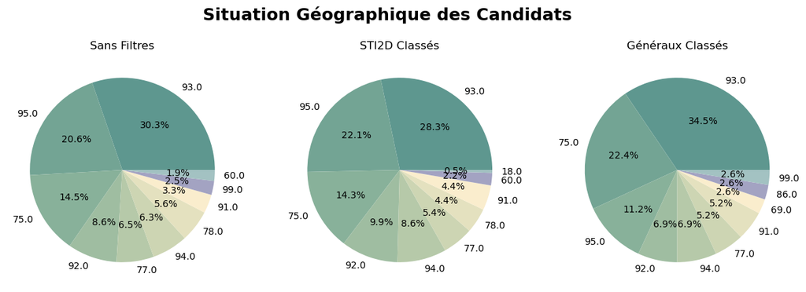

Grâce à l'analyse de ces trois graphiques, il apparaît clairement que le département ayant reçu le plus grand nombre de candidatures est également celui qui compte le plus de candidats sélectionnés, indépendamment de leur catégorie (STI2D ou Généraux). Il s'agit en l'occurrence du département 93, à savoir la Seine-Saint-Denis.

Il est intéressant de noter que les départements suivants présentent des résultats similaires : le Val d'Oise (95), Paris (75), les Hauts-de-Seine (92), l'Essonne (91), la Seine-et-Marne (77) ainsi que le Val-de-Marne (94), qui sont tous des départements de la région Île-de-France.

On remarque également une corrélation entre les départements des candidats et leur proximité avec l'établissement. En effet, plus il y a de candidats proches, plus ils postulent ici. À l'inverse, les candidats qui sont loin postulent moins. C'est pourquoi nous avons une proportion différente avant et après le filtrage des départements proches de Villetaneuse.

Accéder au sommaire

# Conclusion de notre projet

En conclusion, notre algorithme de classement basé sur Jupyter Notebook a été développé dans le but de simplifier et d'optimiser le processus de classement des candidats de ParcourSup. Nous avons travaillé sur un fichier Excel contenant une grande quantité de données relatives aux candidats de ParcourSup et avons mis en place un algorithme complexe permettant de filtrer et de classer ces données en fonction de plusieurs critères.

Notre algorithme prend en compte plusieurs critères tels que les formations actuelles des candidats, les notes trimestrielles et de baccalauréat, la présence de notes en français ainsi que la possession des matières nécessaires au classement. Les candidats sont ensuite classés en fonction de leur performance, avec une catégorie d'élimination, une catégorie de candidats à classer manuellement et une catégorie de candidats classés par notes.

Malgré quelques limites, telles que l'absence de filtrage des "Série Générale" ou de critères géographiques, notre algorithme a permis d'obtenir des résultats prometteurs en filtrant les formations, en mettant l'accent sur les notes en français et en normalisant les notes plusieurs fois. Nous avons réussi à créer deux dataframes avec des informations détaillées sur les candidats, ainsi que sur leurs notes.

Cependant, nous sommes conscients que certaines améliorations pourraient être apportées à l'algorithme, notamment en incluant d'autres critères tels que les appréciations reçues par les candidats ou les notes d'autres matières montrant l'homogénéité du travail des candidats. En somme, notre algorithme de classement peut être utilisé pour simplifier et améliorer le processus de classement des candidats de ParcourSup, en optimisant le temps et les ressources consacrés à cette tâche complexe.

Accéder au sommaire